# What Should Matter and What Actually Matters: Incentives, attention, technology, and behavioral robustness

Andreas C. Drichoutis

Agricultural University of Athens

2026 Behavioral Economics, Science, and Technology (BEST) Conference

September 18, 2026  
College Station, Texas, USA

# 1. When Mechanism Design Meets Homo sapiens

## When Theory Meets the Participant

From formal incentive compatibility to empirical performance

- Incentive compatible mechanisms: under the maintained assumptions, truthful or otherwise optimal behavior is in the participant’s own interest.

FORMAL DESIGN

Mechanism

Rules and payoffs define the Homo economicus benchmark.

→

MECHANISM IN USE

Participant: Homo sapiens

Understands, recognizes, attends, and executes.

→

EMPIRICAL RECORD

Observed behavior

The response recorded in our data.

▲

EMPIRICAL FEEDBACK

Revise assumptions  
Redesign mechanisms  
Improve measurement

◀

**Will real participants use a theoretically sound mechanism as theory assumes?**

## What should matter?

- Economic theory gives us a benchmark:

**Consequential incentives** choices have a real, non-zero chance of affecting participants’ earnings or other outcomes.

**Incentive compatibility** the mechanism makes truthful or target behavior optimal, given its theoretical assumptions.

**Payoff-equivalent variations** changes in implementation that **do not alter the participant’s optimal strategy** should not systematically alter behavior.

**Payoff-irrelevant features** characteristics that do not change incentives, should not affect choices.

**What features survive when the mechanism meets the participant?**

## A stress test of the theoretical benchmark

THE PATTERN TO EXPLAIN **What theory emphasizes may not move behavior. What theory abstracts from sometimes does.** Incentive and implementation architecture varied across more than 3,000 participants.

CONSEQUENTIALITY OF PAYOFFS **Real ↔︎ Hypothetical**

Certain ↔︎ Probabilistic

PAYMENT MECHANISM **Pay all decisions**

Pay one randomly  
Variants of random payment

CHOICE ARCHITECTURE **Magnitude of induced value**

Range of admissible offers

ELICITATION MECHANISM **BDM ↔︎ Second-price auction**

[figure not shown]

## The advantage of induced values: we know the benchmark

- Experimenter assigns value *V* = $2; Participant bids *b.*

TRUTHFUL BID*b* = *V*

RELATIVE DEVIATION  
FROM VALUE**|*b* − *V*|/*V***

**Approximately accurate**|*b* − *V*| / *V* ≤ ε

**Meaningful deviation**|*b* − *V*| / *V* > ε

**Which design features actually determine how closely participants recover the value we know them to have?**

## A stress test of the theoretical benchmark

- We then varied several dimensions that experimental economists care about:

PAYOFF CONSEQUENTIALITY **real or hypothetical**

certain or probabilistic

PAYMENT SCHEME **every decision or one randomly selected decision**

or other variants

PAYOFF SCALE & CHOICE ARCHITECTURE **magnitude of induced value**

range of admissible offers

UNCERTAINTY **random price in BDM**

or other bidders in a second-price auction

- Across the two experiments, we have more than three thousand participants.

## What did not matter

≈ **Real vs. hypothetical**

≈ **Certain vs. probabilistic payment**

≈ **Pay-all vs. pay-one / payment variants**

- The different payment schemes and payoff consequentiality produced remarkably similar deviations from induced values.

## What mattered

- Clear effects on misbidding

01**Magnitude of the induced value**

02**Range / support of possible prices**

03**Elicitation mechanism**

- Induced value and support systematically affected deviations: misbidding ↓ with higher induced values and ↑ with wider support; SPA also generated substantially less misbidding than BDM.
- Same truthful-revelation benchmark. Very different empirical performance.

Mean relative absolute deviation

BDM

**51.9%**

SPA

**17.4%**

## Same value. Same mechanism. Different behavior.

A parameter that should not matter: the BDM support range

- **BDM benchmark:** truthful revelation should be invariant to the support of the random offer distribution.

**IV = $3** $0–$4 → bid = $3

**IV = $3** $0–$6 → bid = $3

**IV = $3** $0–$12 → bid = $3

- Changing the support does not change the weakly dominant strategy.

[figure not shown]

## But experimentally changing only the upper bound moves bids dramatically

- **Experiment 1:** exogenously ↑ the upper bound from $4 → $6 → $12 while holding the IV = $3

SUPPORT $0–$4**$2.68**

Mean WTA

SUPPORT $0–$6**$3.42**

Mean WTA

SUPPORT $0–$12**$5.44**

Mean WTA

$2.68 → $5.44**+103% in elicited WTA for the same $3 IV (over a +200% in support)**

SUPPORT**$0–$4****$0–$6****$0–$12**

UNDERBIDDING**53%****30%****17%**

OVERBIDDING**27%****51%****71%**

## Is this just anchoring on the upper bound?

- **Experiment 2:** exogenously ↑ the IV from $3 → $6 → $9 while holding the support fixed at $0–$12.

IV = $3**+$1.15**

mean deviation  
OVERBID

IV = $6**+$0.23**

mean deviation  
≈ benchmark

IV = $9**−$0.68**

mean deviation  
UNDERBID

**What matters is not only the range; it is where the value sits within that range.**

## The optimal strategy is invariant to the choice environment. Participant behavior is not.

SUPPORTING EVIDENCE**31 treatments**

from 10 previous studies

DIRECTION**25 treatments**

about 81 percent move as predicted.

**Relative placement provides a simple explanation for why overbidding and underbidding coexist in the literature.**Closer to the lower bound: overbidding. Closer to the upper bound: underbidding.

- Importantly, this does not appear to reduce simply to poor comprehension.

**Even when the optimal strategy is unchanged, behavior can respond to implementation details.**

↓

**If some of that sensitivity arises while participants translate incentives into action, simplifying that mapping, is a natural design hypothesis to test.**

## Can strategic simplicity improve performance?

- A natural response is to reduce the contingent reasoning needed to translate incentives into action.

**Strategy-proof** Truthful revelation is a weakly dominant strategy.

**OSP** Obvious dominance at the choice node At the first divergence, the worst outcome from truth-telling is no worse than the best outcome from deviating. *Li (2017)*

**GSO** Future-self-proof game structure Optimal play does not require correctly forecasting one’s own or others’ future actions. *Chakraborty & Kendall (2022)*

**Do mechanisms that reduce contingent reasoning improve empirical performance?**

## Induced-value evidence looked promising

- Chakraborty & Kendall (2022)

INDUCED VALUES **GSO price list → more dominant-strategy play than BDM**

- Brown, Liu & Tsoi (2026)

PRICE LIST **PL (GSO)**

PRICE LIST **PL (NOT GSO)**

GLOBAL BID **BDM**

- Brown, Liu & Tsoi (2026) find that GSO adds little: both price-list formats outperform BDM.

**Maybe it is not GSO per se. Maybe the price-list architecture matters.**

## What happens when we no longer know the right answer?

**Do the apparent advantages of the price-list/GSO approach survive when the researcher no longer knows the underlying valuation?**

MECHANISM**BDM vs. GSO**

INCENTIVES**Real vs. Hypothetical**

SAMPLE**N = 1,184**

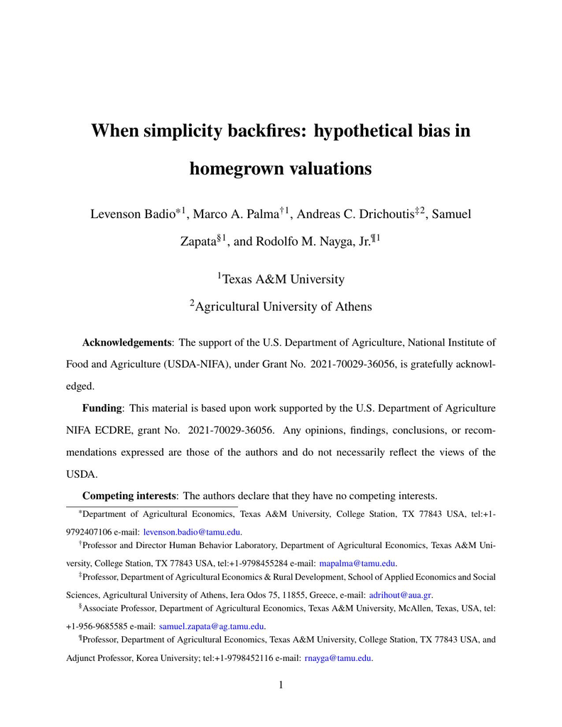

## The simplicity paradox

- **GSO received lower perceived-complexity ratings than BDM.**  
  Hypothetical: 2.17 vs 2.37 · Real: 2.19 vs 2.26
- **Removing real stakes affected WTP differently across the two mechanisms.**

Mechanism

Real incentives

Hypothetical

BDM

Benchmark Real BDM

Within BDM Hypothetical ≈ Real Δ = −0.016 · *p* = .816  
No detectable hypothetical bias

GSO

Under real stakes BDM ≈ GSO Δ = 0.042 · *p* = .596  
The two mechanisms yield statistically indistinguishable WTP

Within GSO Hypothetical > Real Δ = 0.241 · *p* = .003  
Significant upward hypothetical bias  
Remains significant after multiple-testing correction

Under hypothetical incentives: GSO WTP > BDM WTP  
Δ = 0.300 · *p* < .001

**Why does removing stakes leave BDM WTP unchanged but raise WTP under GSO?**

## Not simply misunderstanding

- **Within GSO, understanding barely changes when real stakes disappear.**

  Perceived complexity: 2.37 vs 2.26 (p = .211) · Comprehension: 4.05 vs 6.65 (p < .001)

**Participants still understood the simpler mechanism.**

Misunderstanding is unlikely to explain why removing stakes affects GSO differently.

## The attention channel

What changes is not understanding but how much participants engage with the task.

**Hypothetical incentives**  
real stakes removed

→

**Less deliberation**  
within GSO

→

**Higher WTP**  
less deliberation associated with higher bids

- **With deliberation included, the remaining hypothetical effect becomes smaller and statistically insignificant.**
- **BDM:** Real ≈ Hypothetical in terms of deliberation
- **GSO:** Hypothetical → less deliberation

**Simplification lowers the cost of understanding but may also lower the cost of disengaging.**

Mechanism design may need to preserve attention as well as simplify strategy.

# 2. Looking Inside the Choice Process

## The same choices can hide different processes

[figure not shown]

Segovia · Palma · Lusk · Drichoutis  
Journal of Risk and Uncertainty · 2025

TWO INCENTIVIZED TASKSHL: probabilities vary  
DL: monetary outcomes vary

FOUR DISPLAY FORMATS**Text · probability · money · both**

PROCESS MEASURE**Eye tracking**

## Presentation changed attention but not estimated preferences

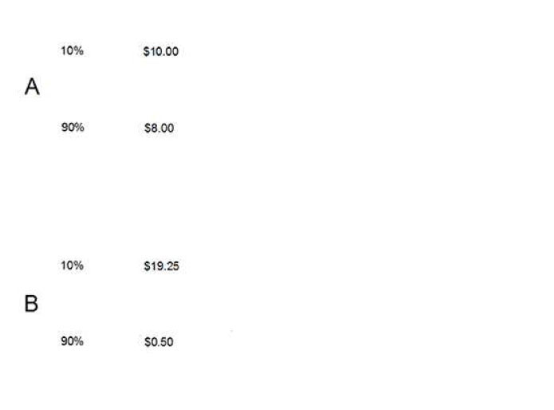

Text

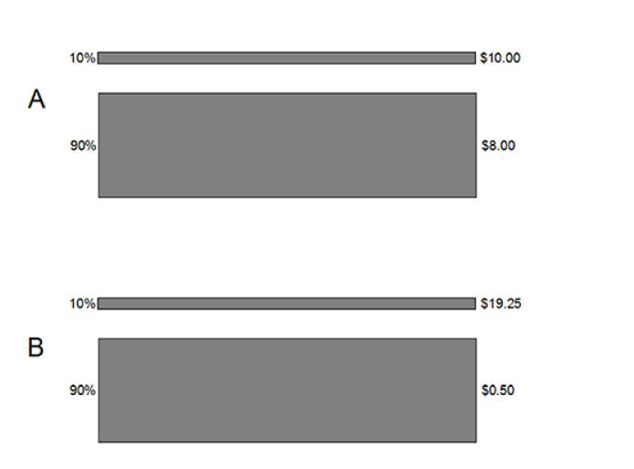

Probability emphasis

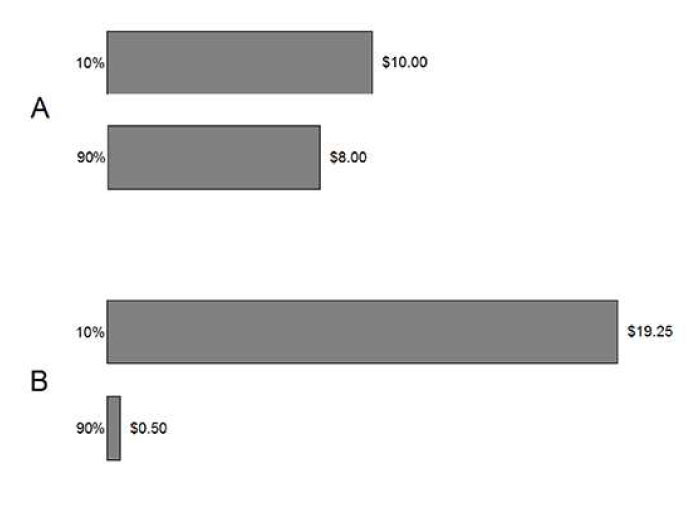

Monetary emphasis

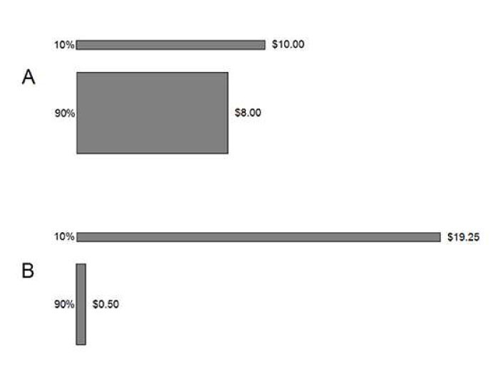

Both

**Attention changed**Display format shifted what participants looked at.

**Preferences stayed stable**No systematic change in estimated risk-preference parameters.

Observed choices look robust. **But the process generating them is not identical.**

## Attention follows the information that matters

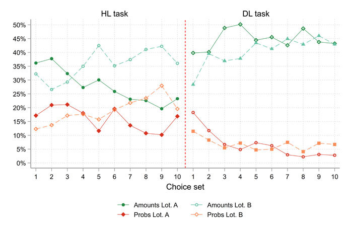

Text

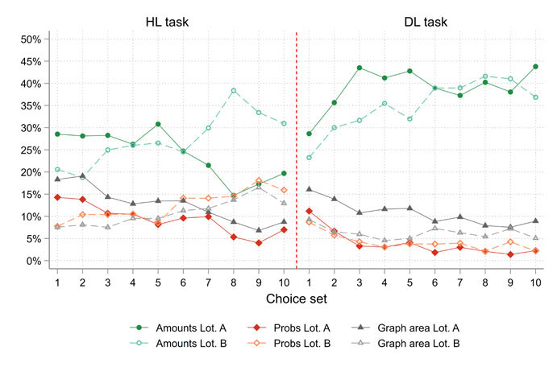

Probability emphasis

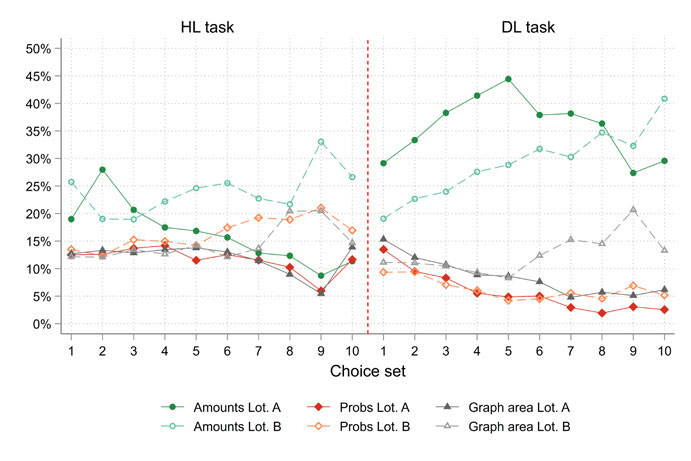

Monetary emphasis

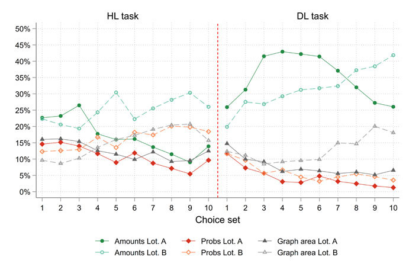

Both

**HL: probabilities change**Monetary outcomes remain constant; attention to them declines through the sequence.

**DL: payoffs change**Probabilities remain constant; attention shifts strongly toward monetary outcomes.

Participants increasingly ignore information they have learned remains constant.

Participants economize on attention: **attention follows the varying attribute.**

## Process data change the economic inference

Same choice data. Different theoretical conclusion.

CHOICE DATA ONLY**RDU collapses to EUT**

Standard observables fail to reject that RDU collapses to EUT.

→

CHOICE + EYE TRACKING**EUT rejected in favor of RDU**

Especially clearly with Tversky-Kahneman probability weighting.

Process data are not merely descriptive but **they can change model selection.**

## What changes when we observe the choice process?

WHAT WE USUALLY OBSERVE**Choice****↓****Structural model****↓****Which theory fits?**

THE EXPANDED INFORMATION SET**Choice process**attention · information use**↓ ↓****Choice****↓****Structural model****↓****Which theory fits?**

01**Stable choices do not imply identical processing.**

02**Process measures contain economically relevant information.**

03**Measurement can change theoretical inference.**

**What we measure determines what we can infer.** Choice-process data can reveal structure that final choices alone leave hidden.

# 3. Scaling Consequential Experiments

## Can consequential experiments scale?

Scaling money is easy. Scaling real economic consequences is not.

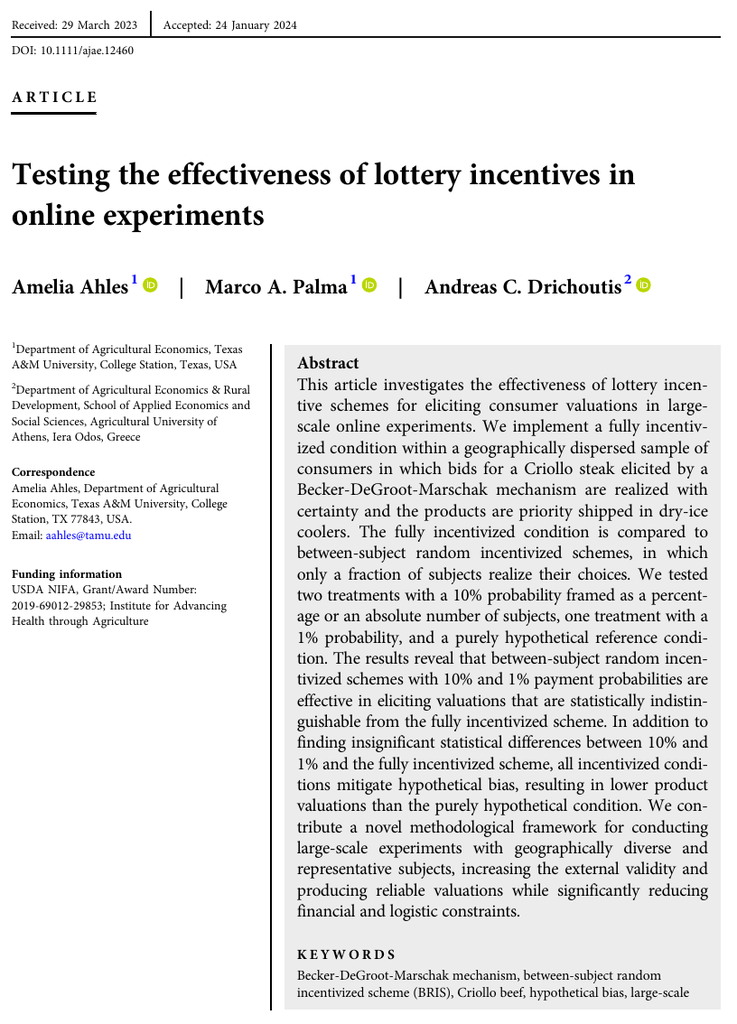

MONEY ONLY**digital payment****low marginal cost of the logistics ivolved***easy to scale*

TANGIBLE GOODS**procure · package · ship****spoilage and replacement risk***hard to scale*

A HARD CASE **2,072 U.S. beef consumers**

All 50 states + D.C. + Puerto Rico

BDM: exchange a conventional steak for a sustainable Criollo steak

[figure not shown]

National geographic reach

[figure not shown]

Physical fulfillment

**200 steaks shipped**vacuum sealed · dry ice · two-day delivery

Can we preserve consequentiality **without realizing every physical outcome?**

## Consequentiality did not require certainty

Only a randomly selected fraction of participants had their decisions realized.

**100%**FULL

**10%**BRIS

**50/500**BRIS

**1%**BRIS

**0%**HYPOTHETICAL

Realization probability ↓ **Marginal cost of the logistics ↓** But does behavior change?

MEAN WTP PREMIUM

**$1.80**[$1.59, $2.01]100%

**$1.81**[$1.71, $1.91]10%

**$1.81**[$1.71, $1.91]50/500

**$1.83**[$1.74, $1.92]1%

**$2.16**[$2.06, $2.26]0%

The crucial discontinuity was between **some real consequence and none at all.**

## How low can incentives go?

Cost savings are immediate. Credibility is a repeated-game problem.

ONE-SHOT EXPERIMENT**1% chance****↓****still credible****↓***behavior ≈ 100%*

REPEATED PARTICIPATION**1% × many studies****↓****realization is rarely experienced****↓***“Is this really consequential?”*

EVIDENCE**1%, 10%, and 100% are indistinguishable here.**

OPEN QUESTION**Does repeated exposure to extremely low probabilities erode credibility?**

FORMAL CONSEQUENTIALITY**Pr(realization) > 0**

BEHAVIORAL CONSEQUENTIALITY**The participant believes implementation is real.**

Scaling is not just increasing *N*. **We also need evidence from larger, more dispersed populations without costs and logistical demands increasing proportionally.**

## Can machines substitute for participants ?

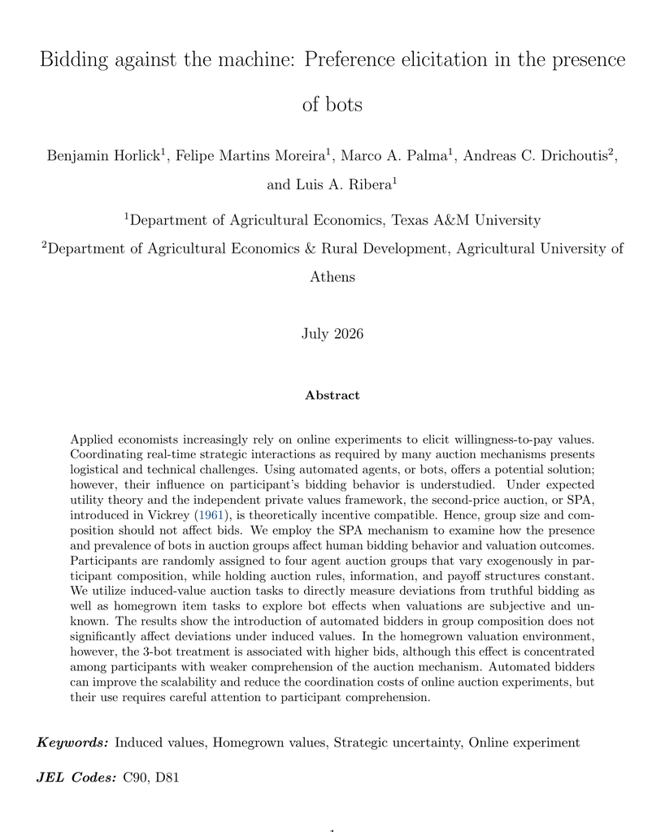

Some experiments require people not merely to enroll but to arrive together.

INDIVIDUAL TASK**1 participant arrives****↓***proceed*

INTERACTIVE AUCTION**1 participant arrives****↓****needs 3 more humans****↓***waiting → attrition → recruit more*

SECOND-PRICE AUCTION BENCHMARK **Truthful bidding is weakly dominant regardless of what others bid.**

Replacing humans with known automated bidders should not change the optimal strategy.

0 BOTS

[figure not shown]

1 BOT

[figure not shown]

2 BOTS

[figure not shown]

3 BOTS

[figure not shown]

**N = 1,101 humans**

Bot bids independently drawn from a known U($0, $8)

Induced values + homegrown values

Can machines remove the matching constraint **without changing human bidding?**

## Bots remove the coordination bottleneck

As bots fill seats, fewer humans must be present at the same time.

THEORETICAL BENCHMARK**Replacing human competitors with known automated bidders does not change the weakly dominant truthful strategy.**

OBSERVED ATTRITION

0 bots**58–60%**

1 bot**42%**

2 bots**24–30%**

3 bots**14–16%**

TARGET: 270 COMPLETERS

ALL HUMAN**~657 entrants****$1,971**

3 BOTS**~318 entrants****$954**

*≈ $1,017 saved*

Bots reduced the coordination burden. **Did bidding remain unchanged, as theory predicts?**

## Behavioral neutrality has a comprehension boundary

INDUCED VALUES

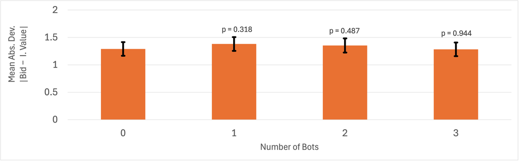

**Bot composition did not systematically change deviations from truthful bidding.**

HIGH COMPREHENSION**WTP essentially stable**

0 → 1 → 2 → 3 bots

LOWER COMPREHENSION**Bids rise relative to all-human groups**

+ $0.58 · + $0.47 · + $0.60

Machines can substitute for participants but **behavioral neutrality might depend on comprehension.**

## Homegrown values reveal a boundary condition

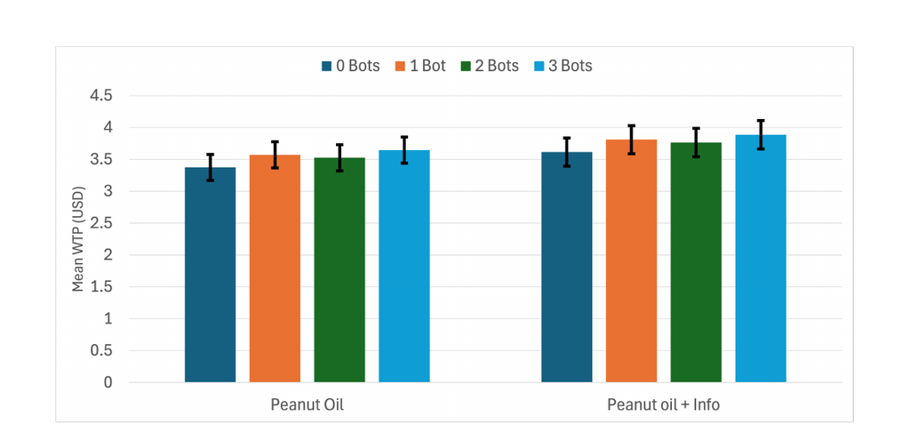

POOLED ESTIMATES **The 3-bot coefficient is positive.**

But the bot indicators are not jointly significant, and the pattern is not monotonic.

COMPREHENSION SPLIT **Full comprehension: bids remain stable.**

With comprehension errors, bids are $0.47–$0.60 higher across the bot treatments.

Bots affect bidding mainly among participants with lower comprehension

## What survives when experiments scale?

COST OF REALIZATION**BRIS****↓***turns implementation cost to a random lottery*

100% → 10% → 1%: valuations stable  
0%: behavior changed

COST OF COORDINATION**BOTS****↓***substitute with automated agents*

attrition and recruitment fell  
neutrality depended on comprehension

Scalability is not just sample size issue; it is a property of **implementation as well.**

**So far, technology has been infrastructure. What happens when people start responding to the machine as an agent?**

# 4. Machines as Social Actors

## When the machine becomes the agent

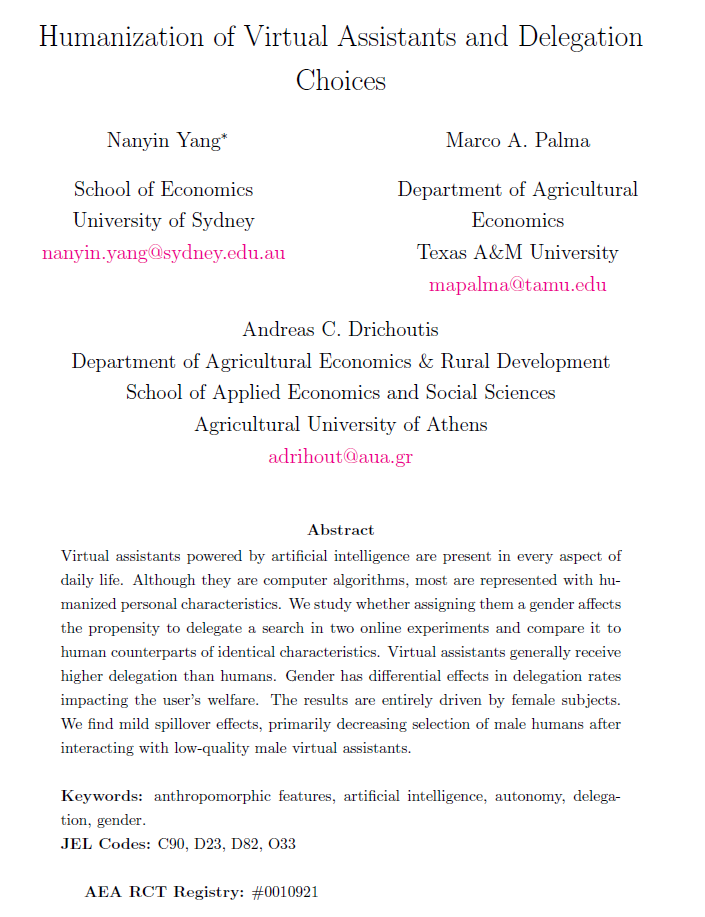

Yang, Palma & Drichoutis

Same economic performance. **Different identity.**

SECTION 3**Machine as infrastructure**

fills a seat · reduces waiting · lowers cost

**→**

SECTION 4**Machine as agent**

searches · advises · receives authority

SELF-SEARCH**costly effort**

keep control

OR

DELEGATE**costless search**

give authority to an assistant

If performance is held fixed, **does identity still change delegation?**

## Quality matters but does not determine delegation

LOW QUALITY · 60%**Self-search is optimal****Predicted delegation: 0%**

HIGH QUALITY · 80%**Delegation is optimal****Predicted delegation: 100%**

OBSERVED DELEGATION0%100%

Low quality

**56–61%**

High quality

**67–70%**

HumanVirtual

## Social cues are not portable

SAME QUALITY **+** SAME PAYOFFS **+** SAME TASK **+** **Jennifer · Charles · no name**

MOST COMPARISONS **little detectable effect**

Gender cues did not consistently alter delegation.

ONE EXCEPTION **Low-quality human assistant: +9.8% male cue vs no cue**

No corresponding effect for the low-quality virtual assistant.

**The same social cue does not necessarily travel from a human to a machine.**

## Spillovers are possible but not generic

BLOCK 1**Experience a virtual assistant**

quality × gender cue

**→**

BLOCK 2**Choose a human assistant (Mary, Elizabeth, Thomas or Richard)**

all candidates: 80% quality

AGGREGATE RESULT **No clear shift**

Prior virtual-assistant gender did not significantly change the gender of the human assistant chosen next.

EXPLORATORY SUBGROUP: **Female participants after a low-quality virtual assistant**

FEMALE vs. GENDERLESS VA **+9.6 pp** 95% CI: −11.8 to 31.1 pp  
not statistically significant

MALE vs. GENDERLESS VA **+30.0 pp** 95% CI: 10.7 to 49.4 pp  
*p* < .01

Outcome: probability of choosing a **female human assistant**.

A possible behavioral afterlife of machine interaction is **limited to a narrow, exploratory pattern.**

# 5. From Elicited Preferences to Consequential Behavior

## Do elicited preferences predict what people actually do?

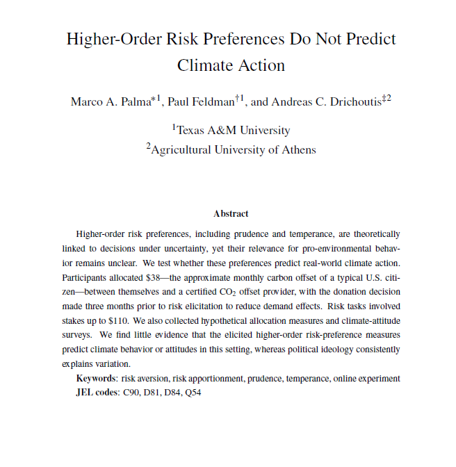

Palma, Feldman & Drichoutis

ELICIT PREFERENCES**risk aversion · prudence · temperance**wealth uncertainty + timing uncertainty

**?**

CONSEQUENTIAL BEHAVIOR**give up money today**to reduce uncertain future climate damages

JANUARY**$38 climate allocation**keep it or fund permanent CO₂ mitigation

**→***THREE MONTHS***→**

APRIL**42 incentivized choices**risk preferences over wealth and delay

If the measures capture meaningful traits, **do they predict behavior beyond the elicitation task?**

## Preferences do not travel automatically

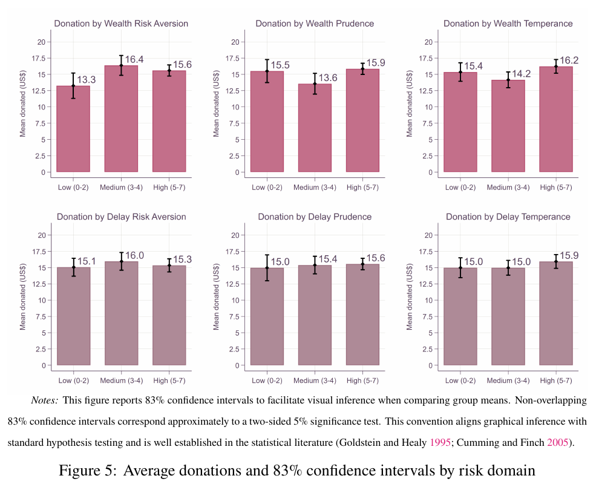

Average climate donation by risk domain and intensity

THE PREDICTIVE TEST**Essentially, no.**

Donations remain similar across low, medium, and high classifications.

SIX RISK MEASURES**little systematic predictive evidence**

## What does travel to climate outcomes?

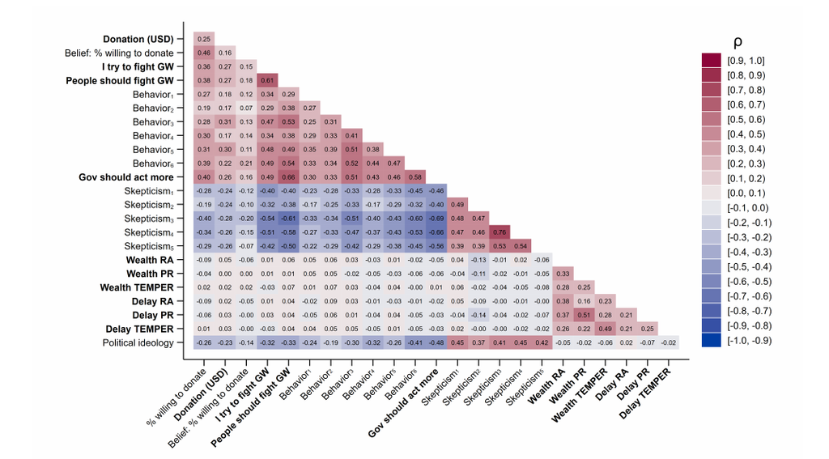

Spearman rank correlations across climate outcomes and preference measures

POLITICAL IDEOLOGY**consistently related to climate outcomes**

## A closer domain match raises the bar

[figure not shown]

Barba, Drichoutis, Palma & Cerroni

What if uncertainty is directly tied to people’s **livelihoods?**

weather · yields · pests · prices · insurance · production

STATED**insurance interest · workshop registration**

SELF-REPORTED**insurance · active defense · investments**

OBSERVED**workshop attendance**

ADMINISTRATIVE**insurance record · area · value**

**When intentions give way to observed behavior, which preference–behavior links survive?**

## Preferences travel but selectively

THE TRAITS  
ARE PRESENT**risk aversion · prudence · temperance**all three traits above a random-choice benchmark

OUTCOME**RISK AVERSION****PRUDENCE****TEMPERANCE**

Workshop registration*·**↑**·*

Observed attendance*·**·**·*

Active-defense practices*·**·**↓*

Administrative insurance*·**·**↑*

Insured value*·**·**↑*

**Temperance predicts the form of risk management not simply more risk management.**

## When probability becomes part of the policy

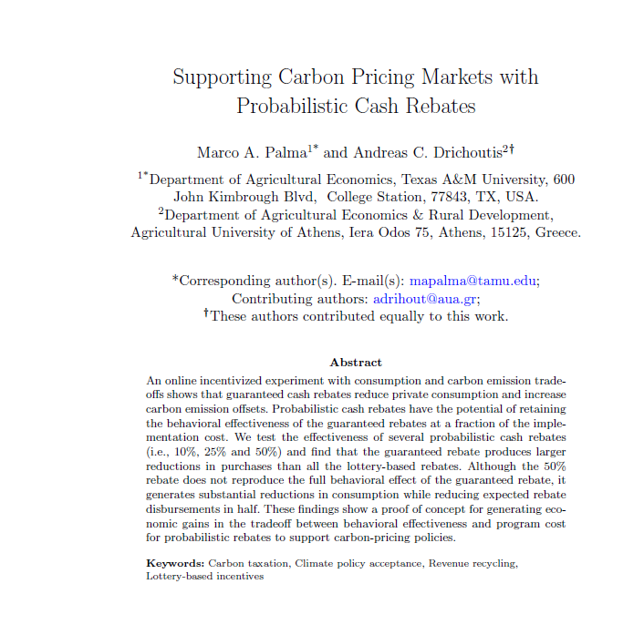

Palma & Drichoutis

PROBABILITY AS IMPLEMENTATION**BRIS**

realization probability ↓  
Pr(realization)>0

**behavior may remain stable**

PROBABILITY AS POLICY INCENTIVE**Carbon rebate**

rebate probability ↓  
expected rebate falls relative to consumption value  
relative payoffs change

**behavior should respond**

**BUY MORE**private consumption ↑CO₂ removed ↓

**OR**

**BUY LESS**private consumption ↓50 lbs CO₂ retired per unit forgone

Reducing implementation probability and reducing the probability of a policy reward need not be behaviorally equivalent.

## How did participants make the consumption choice?

In each round, participants chose how many of four units to buy.

UNIT 1**$15.00**private value**$13 price**

UNIT 2**$14.50**private value**$13 price**

UNIT 3**$14.00**private value**$13 price**

UNIT 4**$13.50**private value**$13 price**

BUY *n* UNITS**Receive their private consumption value**and pay $13 per unit

**OR**

FORGO 4 − *n* UNITS**50 lbs of CO₂ retired per unit**plus eligibility for a $2 rebate per unit forgone

REBATE PROBABILITY**0% · 10% · 25% · 50% · 100%**Assigned between participants; probability applied to the rebate—not to the private consumption payoff.

**4 repeated choices**One round was randomly selected to determine the monetary bonus and corresponding carbon retirement.

## Guaranteed rebates work better but cost more

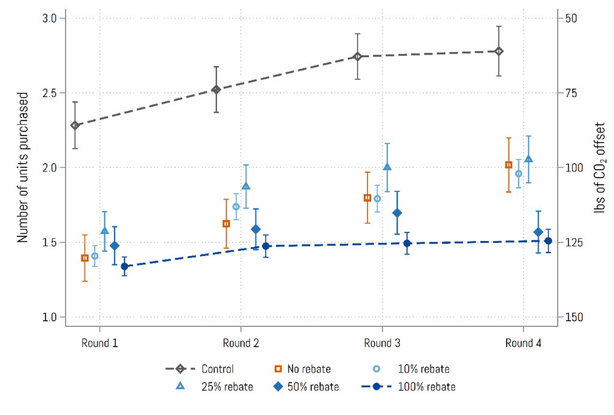

**WAVE 1** Full experimental design

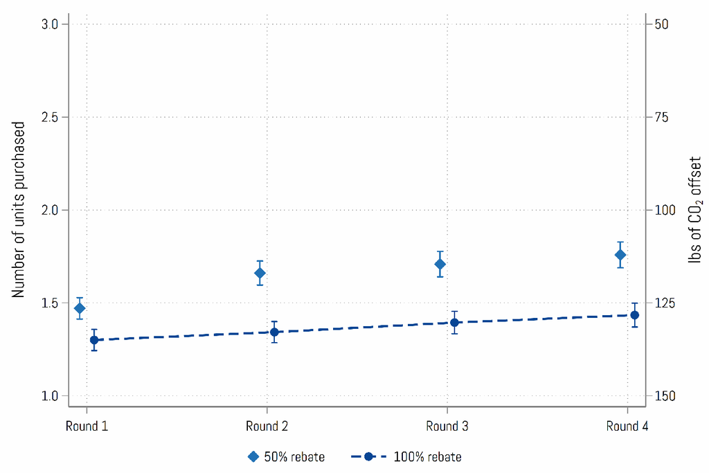

**WAVE 2** Focused 50%–100% comparison

WAVE 2**Guaranteed rebate lowers purchases in every round**all four comparisons statistically significant

POOLED ESTIMATE**50% rebate: +0.244 units purchased**

## The 50% rebate saves money but gives up some effect

50% REBATE**$2.35**

expected rebate expenditure

1.649 units purchased

100% REBATE**$5.26**

expected rebate expenditure

1.368 units purchased

MOVING FROM 50% TO 100%**+$2.91**

additional expected expenditure

0.282 fewer purchases · 14.08 additional lbs CO₂ offset

NOT EQUIVALENT**The guaranteed rebate produces the larger behavioral response.**

BUT CHEAPER**The 50% rebate saves $2.91 in expected rebate expenditure per participant.**

IS THE EXTRA EFFECT WORTH IT?**$2.91/14.08 lbs CO₂ ≈ $0.207 per lb CO₂ or $456 per additional metric tonne of CO₂**Above central EPA 2030 damage estimates of roughly $220–$240 per tonne (2020 dollars)*Illustrative comparison from a stylized experiment—not a complete policy cost-effectiveness estimate.*

**Behavioral effectiveness and fiscal efficiency need not be maximized by the same design.**

# 6. The Road Ahead

## A framework for behavioral robustness

THEORY TELLS US**WHAT SHOULD MATTER**

**↔︎**

EXPERIMENT REVEALS**WHAT ACTUALLY MATTERS**

MECHANISM PERFORMANCE**Does behavior respond as theory predicts?**

Incentives · payment mechanism · uncertainty

INFERENCE**Do conclusions survive richer process measurement?**

Attention · information use · model discrimination

SCALE & TECHNOLOGY**Does behavior survive changes in implementation?**

Probabilistic realization · coordination · automation

SOCIAL CONTEXT**Does technology alter the meaning of the environment?**

Agency · representation · social cues

PREDICTION**Does an elicited measure travel?**

To a particular consequential behavior · in a particular domain

**Behavioral robustness lives in the gap between the two.**It concerns whether an economic conclusion survives the appropriate stress test and whether we understand its boundary conditions.

## When should behavior respond?

Does the theoretical benchmark predict a response or stability?

THEORY PREDICTS A RESPONSE**Behavior changes in the predicted direction**

Theory and behavior align.

Example: a guaranteed rebate strengthens the reward for buying less.

THEORY PREDICTS A RESPONSE**No detectable behavioral change**

Possible failure of behavioral responsiveness.

First check: effect size · power · comprehension · engagement.  
If these are adequate, the mechanism is not robust to this relevant change.

THEORY PREDICTS STABILITY**The main conclusion remains stable**

Robust to the tested variation.

Example: automated bidders preserve behavior when the strategic problem remains equivalent.

THEORY PREDICTS STABILITY**The main conclusion changes**

Possible failure of behavioral stability.

The mechanism is not robust to this change—or theory misclassified it as irrelevant.  
Example: changing the BDM support range moves bids despite an unchanged truthful strategy.

DEFINITION**A mechanism is behaviorally robust when its main economic conclusions respond appropriately to economically relevant changes, remain reasonably stable to theoretically irrelevant implementation changes, and have identifiable boundary conditions when they do not.**

## Study the mechanism-in-use

Observed behavior is jointly produced by the mechanism and the environment in which participants encounter it.

MECHANISMincentive rule  
realization probability  
strategic uncertainty

**×**

PARTICIPANTcomprehension  
attention  
deliberation

**×**

INTERFACEsupport range  
display format  
information emphasis

**×**

OPERATIONAL ENVIRONMENThuman or automated bidders  
coordination  
fulfillment

**×**

CONTEXTpersonal relevance  
social cues  
behavioral domain

**↓****OBSERVED BEHAVIOR**The implementation helps determine the behavior the mechanism produces.

SPECIFY**what should and should not matter**

VARY**implementation deliberately**

MEASURE**process and behavioral outcomes**

REPORT**sensitivity and boundaries**

Evaluate the mechanism **as formally specified** as well **as implemented and experienced**.

## What should matter and what actually matters

**Specify the benchmark.** **Stress-test the implementation.** Study the mechanism-in-use.

The goal is not to make behavior invariant to the world. **The goal is to understand which parts of the world our economic mechanisms can safely ignore and which they cannot.**

## Thank you

**Thank you!** Questions and discussion Andreas C. Drichoutis · Agricultural University of Athens

## References

Ahles, Amelia, Marco A. Palma, and Andreas C. Drichoutis. 2024. “Testing the Effectiveness of Lottery Incentives in Online Experiments.” *American Journal of Agricultural Economics* 106: 1435–53. https://doi.org/10.1111/ajae.12460.

Badio, Levenson, Marco A. Palma, Andreas C. Drichoutis, Samuel Zapata, and Rodolfo M. Nayga Jr. 2026. “When Simplicity Backfires: Hypothetical Bias in Homegrown Valuations.” Unpublished manuscript.

Barba, Francesca R., Andreas C. Drichoutis, Marco A. Palma, and Simone Cerroni. 2026. “Higher-Order Risk Preferences and Risk-Management Behavior: Evidence from Italian Winegrowers.” Unpublished manuscript.

Drichoutis, Andreas C., Marco A. Palma, and Paul J. Feldman. 2026. “Incentives and Payment Mechanisms in Preference Elicitation.” *Experimental Economics*, 1–17. https://doi.org/10.1017/eec.2026.10042.

Horlick, Benjamin, Marco A. Palma, and Andreas C. Drichoutis. 2026. “Explaining Misbidding Direction in Preference Elicitation.” Unpublished manuscript.

Horlick, Benjamin, Felipe Martins Moreira, Marco A. Palma, Andreas C. Drichoutis, and Luis A. Ribera. 2026. “Bidding against the Machine: Preference Elicitation in the Presence of Bots.” Unpublished manuscript.

Palma, Marco A., and Andreas C. Drichoutis. 2026. “Supporting Carbon Pricing Markets with Probabilistic Cash Rebates.” Unpublished manuscript.

Palma, Marco A., Paul J. Feldman, and Andreas C. Drichoutis. 2026. “Higher-Order Risk Preferences Do Not Predict Climate Action.” Unpublished manuscript.

Segovia, Michelle S., Marco A. Palma, Jayson L. Lusk, and Andreas C. Drichoutis. 2025. “Visual Formats in Risk Preference Elicitation: What Catches the Eye?” *Journal of Risk and Uncertainty* 70: 275–303. https://doi.org/10.1007/s11166-025-09455-9.

Yang, Nanyin, Marco A. Palma, and Andreas C. Drichoutis. 2026. “Humanization of Virtual Assistants and Delegation Choices.” Unpublished manuscript.